# Homework 7: Time & Space

Brendan Smith

March 2016

**Objective Statement:** Flooding is an important phenomenon that recharges ground water in a natural and efficient manner; however, as with most things political, evidence and a dollar amount must be disseminated. The Cosumnes River is the last major undammed river of the Sierra Nevada, and runs through the central valley south of Sacramento. In 1907 the USGS placed a gaging station that logs daily flows in the Cosumnes river at the Michigan Bar (MHB) location. This assignment is designed to introduce time series data, extraction of time series data from an online source and time series data manipulation and plotting.

```r
# Load libraries
source("getCDEC_fixed.R")
source("getdailyUSGS.R")
```

**Methods:** Data is extracted from the USGS website, where it was collected via a gaging station along the Cosumnes River at the MHB station. The time series data is converted to different units and interpretted using typical statistical tools such as mean, max and autocorrelation.

**Data:** The data utilized in this assignment is downloaded directly from the CDEC and USGS websites. For a majority of the exercise, we are handling daily discharge levels of the Cosumnes River at the Michigan Bar gage. This data is assumed to be accurate and “gold standard”.

**Results:**

## Step 1 - Data Retrieval and Troubleshooting

We begin by exploratory data analysis of the time series data of discharge at the Michigan Bar USGS gaging station along the Cosumnes river.

```r
# grab CSV data from USGS Website
# The getCDEC_fixed.R file was modified to return the filename upon
# completion for easier data manipulation
filename <- get.CDEC("MHB","D","41","2011/10/01","2012/09/30")
```

```
## 'data.frame':    366 obs. of  4 variables:
##  $ date     : POSIXlt, format: "2011-10-01" "2011-10-02" ...
##  $ time     : chr  "0000" "0000" "0000" "0000" ...
##  $ sensor_41: num  35 34 34 36 54 115 109 84 70 65 ...
##  $ datetime : POSIXct, format: "2011-10-01" "2011-10-02" ...
## [1] "file downloaded and saved here: /Users/brendansmith/GitHub/ES207/HW7"
```

```r
#Y # Enter Y at prompt to write csv file
```

```r
# Call function created to pull USGS data. This also saves to workspace under "usgs.dat"
get.dailyUSGS("11335000","00060","1907-10-01","2012-09-30")
```

## Step 2 - Formatting and EDA

```r
colnames(usgs.dat)[3:5] = c("datetime","discharge_cfs","dat_qvalue")

usgs.dat$datetime = as.POSIXct(usgs.dat$datetime, tz = "America/Los_Angeles")
#you must convert a factor to a character, then to double...
usgs.dat$discharge_cfs = as.double(as.character(usgs.dat$discharge_cfs))
```

```r
usgs.dat$discharge_afd <- usgs.dat$discharge_cfs/(60*60*24*2.3E5)
summary(usgs.dat)
```

```
##     V1               V2           datetime
##  USGS:38352   11335000:38352   Min.   :1907-10-01 00:00:00
##                                1st Qu.:1933-12-30 18:00:00
##                                Median :1960-03-31 12:00:00
##                                Mean   :1960-03-31 11:37:49
##                                3rd Qu.:1986-07-01 06:00:00
##                                Max.   :2012-09-30 00:00:00
##  discharge_cfs     dat_qvalue  discharge_afd
##  Min.   :    0.0   A  :38338   Min.   :0.000e+00
##  1st Qu.:   27.0   A:e:   14   1st Qu.:1.359e-09
##  Median :  102.0               Median :5.133e-09
##  Mean   :  495.1               Mean   :2.491e-08
##  3rd Qu.:  546.0               3rd Qu.:2.748e-08
##  Max.   :61600.0               Max.   :3.100e-06
```

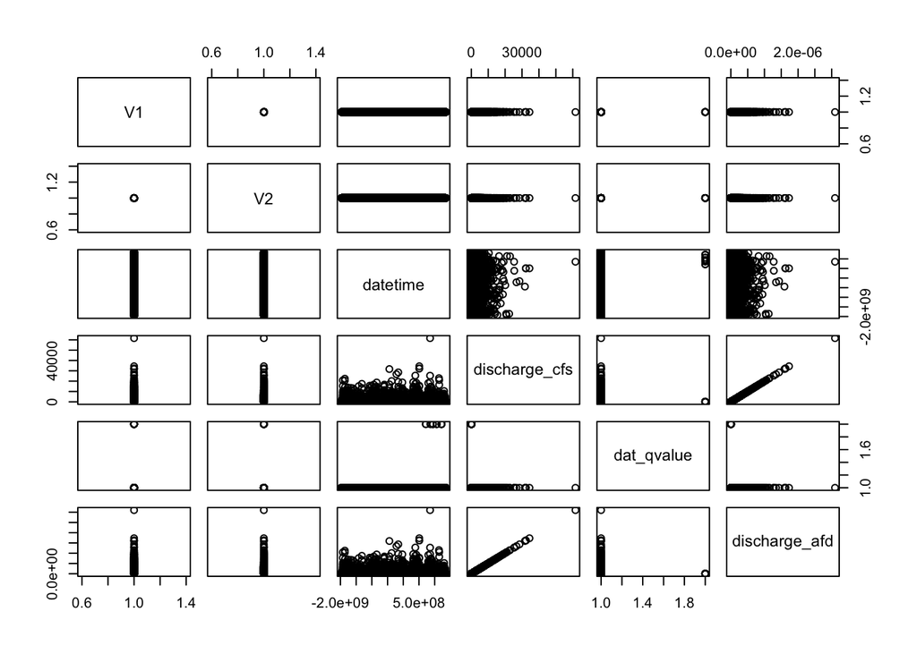

```r
plot(usgs.dat)
```